# Adherencia HM en el Centro de Simulación

Tasa de cumplimiento de la higiene de manos

Authors

Affiliation

Mario Camacho

Facultad de Medicina

Fernando Neria

Facultad de Medicina

Published

January 7, 2026

Modified

January 28, 2026

- Inicio
- Ingesta de datos
- Resumen y gráficos descriptivos
- Análisis estadístico sobre la adherencia de la higiene de manos

# Tasa de cumplimiento de HM por curso

```
Tasas de cumplimiento e intervalos de confianza del 95%.
```

Tasas de cumplimiento con IC del 95%

|  | Tasa de cumplimiento | IC 95 % inf | IC 95 % sup |
| --- | --- | --- | --- |
| 4º (pre-formación) | 0.102 | 0.074 | 0.138 |
| 4º (post-formación corto plazo) | 0.507 | 0.387 | 0.626 |
| 5º (post-formación largo plazo) | 0.261 | 0.229 | 0.295 |

```
Comparamos la tasa de cumplimiento por curso.
Calculamos la diferencia de proporciones y obtenemos el p-valor ajustado por Bonferroni.
```

Test de proporciones entre las tasas de cumplimiento

| Grupo 1 | Grupo 2 | n 1 | n 2 | Tasa cumplimiento 1 | Tasa cumplimiento 2 | Diferencia | p valor |
| --- | --- | --- | --- | --- | --- | --- | --- |
| 4º (pre-formación) | 4º (post-formación corto plazo) | 371 | 73 | 0.102 | 0.507 | -0.404 | <0.001 |
| 4º (pre-formación) | 5º (post-formación largo plazo) | 371 | 698 | 0.102 | 0.261 | -0.158 | <0.001 |
| 4º (post-formación corto plazo) | 5º (post-formación largo plazo) | 73 | 698 | 0.507 | 0.261 | 0.246 | <0.001 |

**Tip**

El aumento del cumplimiento de la higiene de manos entre pre y post-corto es significativo.  
La diferencia entre post-corto y post-largo es significativa, lo que sugiere que el efecto de la formación se disipa.  
Aun así, el cambio entre pre y post-largo sigue siendo significativo, por lo que **parece** que la formación tiene efecto a **nivel global** en la adherencia a la higiene de manos.

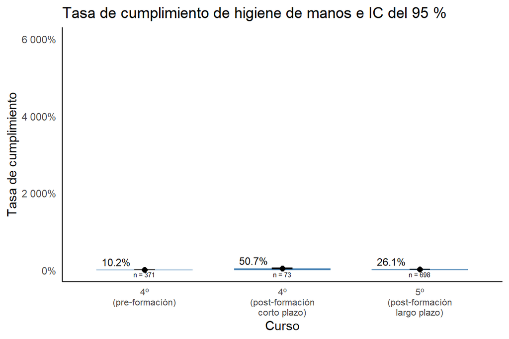

# Tasa de cumplimiento de HM por curso (filtrado por escenario)

**Tip**

El único escenario donde tiene sentido medir la trazabilidad del efecto a corto y largo plazo es en el escenario Consulta.

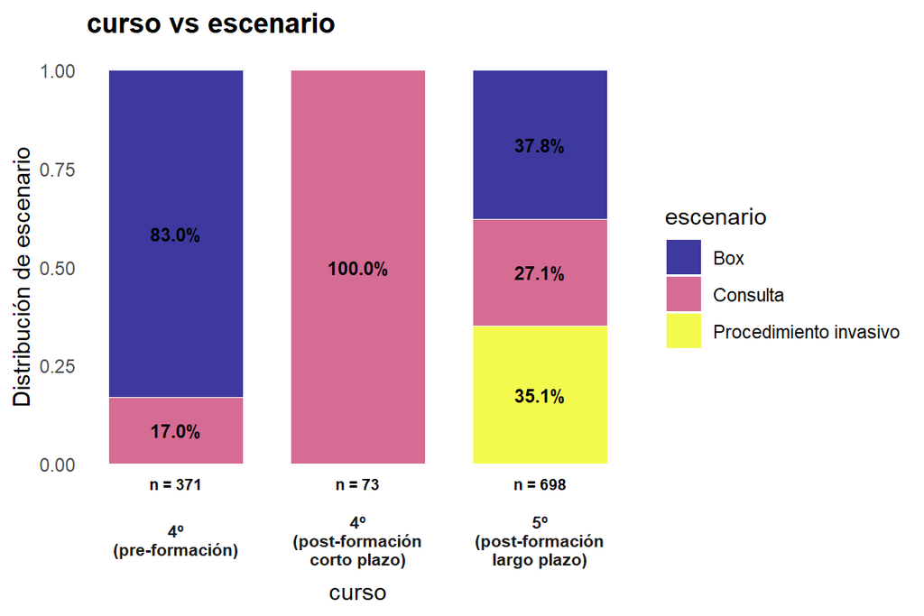

```
Tasas de cumplimiento por tipo de escenario e intervalos de confianza del 95%.
```

Tasas de cumplimiento con IC del 95%

|  | Tasa de cumplimiento | IC 95 % inf | IC 95 % sup |
| --- | --- | --- | --- |
| Box | 0.038 | 0.024 | 0.058 |
| Consulta | 0.375 | 0.323 | 0.431 |
| Procedimiento invasivo | 0.461 | 0.398 | 0.526 |

```
Comparamos la tasa de cumplimiento por escenario.
Calculamos la diferencia de proporciones y obtenemos el p-valor ajustado por Bonferroni.
```

Test de proporciones entre las tasas de cumplimiento

| Grupo 1 | Grupo 2 | n 1 | n 2 | Tasa cumplimiento 1 | Tasa cumplimiento 2 | Diferencia | p valor |
| --- | --- | --- | --- | --- | --- | --- | --- |
| Box | Consulta | 572 | 325 | 0.038 | 0.375 | -0.337 | <0.001 |
| Box | Procedimiento invasivo | 572 | 245 | 0.038 | 0.461 | -0.423 | <0.001 |
| Consulta | Procedimiento invasivo | 325 | 245 | 0.375 | 0.461 | -0.086 | 0.145 |

**Tip**

El procedimiento invasivo solo aparece en 5º (post-largo), representa un tercio de las oportunidades de higiene de manos y, además, tiene una alta adherencia (~46 %).

**Important**

Se vuelve a comparar la tasa de cumplimiento de la HM entre cursos **sin** el escenario de procedimiento invasivo.

```
Tasas de cumplimiento e intervalos de confianza del 95%.
```

Tasas de cumplimiento con IC del 95%

|  | Tasa de cumplimiento | IC 95 % inf | IC 95 % sup |
| --- | --- | --- | --- |
| 4º (pre-formación) | 0.102 | 0.074 | 0.138 |
| 4º (post-formación corto plazo) | 0.507 | 0.387 | 0.626 |
| 5º (post-formación largo plazo) | 0.152 | 0.120 | 0.189 |

```
Comparamos la tasa de cumplimiento por curso.
Calculamos la diferencia de proporciones y obtenemos el p-valor ajustado por Bonferroni.
```

Test de proporciones entre las tasas de cumplimiento (sin el escenario de procedimiento invasivo)

| Grupo 1 | Grupo 2 | n 1 | n 2 | Tasa cumplimiento 1 | Tasa cumplimiento 2 | Diferencia | p valor |
| --- | --- | --- | --- | --- | --- | --- | --- |
| 4º (pre-formación) | 4º (post-formación corto plazo) | 371 | 73 | 0.102 | 0.507 | -0.404 | <0.001 |
| 4º (pre-formación) | 5º (post-formación largo plazo) | 371 | 453 | 0.102 | 0.152 | -0.050 | 0.132 |
| 4º (post-formación corto plazo) | 5º (post-formación largo plazo) | 73 | 453 | 0.507 | 0.152 | 0.355 | <0.001 |

**Tip**

El aumento del cumplimiento de la higiene de manos entre pre y post-corto sigue siendo significativo.  
La diferencia entre post-corto y post-largo sigue siendo significativa, lo que sugiere que el efecto de la formación se disipa.  
PERO el cambio entre pre y post-largo no es significativo para una confianza del 95 %, por lo que la formación tiene **no tiene efecto** a largo plazo en la adherencia a la higiene de manos si no contamos con el escanario de procedimiento invasivo.

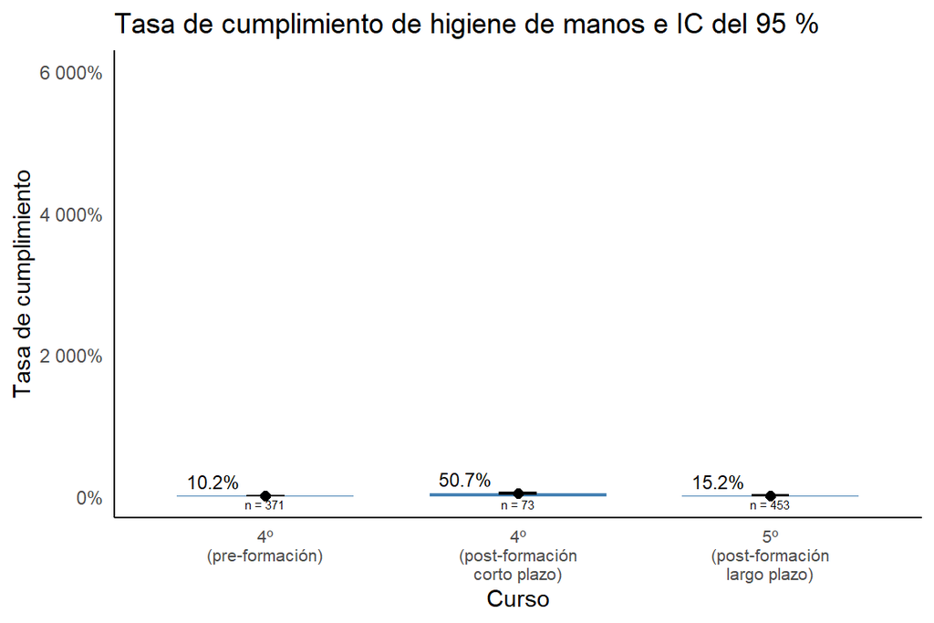

Seguimos con las comparaciones de tasa de adherencia por escenario.

**Note**

**Box**

```
Tasas de cumplimiento e intervalos de confianza del 95%.
```

Tasas de cumplimiento en el escenario BOX con IC del 95%

[output not shown]

Calculamos la diferencia de la tasa de cumplimiento y obtenemos el p-valor ajustado por Bonferroni.

Test de proporciones entre las tasas de cumplimiento en el escenario BOX

| Grupo 1 | Grupo 2 | n 1 | n 2 | Tasa cumplimiento 1 | Tasa cumplimiento 2 | Diferencia | p valor |
| --- | --- | --- | --- | --- | --- | --- | --- |
| 4º (pre-formación) | 5º (post-formación largo plazo) | 308 | 264 | 0.045 | 0.03 | 0.015 | 0.471 |

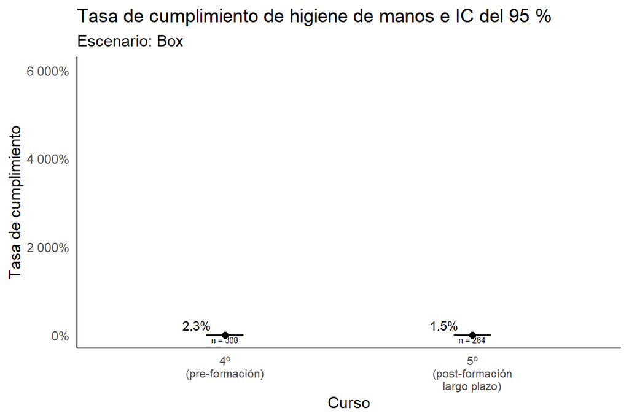

**Note**

**Consulta**

```
Tasas de cumplimiento e intervalos de confianza del 95%.
```

Tasas de cumplimiento en el escenario Consulta con IC del 95%

[output not shown]

Calculamos la diferencia de la tasa de cumplimiento y obtenemos el p-valor ajustado por Bonferroni.

Test de proporciones en el escenario Consulta entre las tasas de cumplimiento

| Grupo 1 | Grupo 2 | n 1 | n 2 | Tasa cumplimiento 1 | Tasa cumplimiento 2 | Diferencia | p valor |
| --- | --- | --- | --- | --- | --- | --- | --- |
| 4º (pre-formación) | 4º (post-formación corto plazo) | 63 | 73 | 0.381 | 0.507 | -0.126 | 0.582 |
| 4º (pre-formación) | 5º (post-formación largo plazo) | 63 | 189 | 0.381 | 0.323 | 0.058 | 1.000 |
| 4º (post-formación corto plazo) | 5º (post-formación largo plazo) | 73 | 189 | 0.507 | 0.323 | 0.184 | <0.05 |

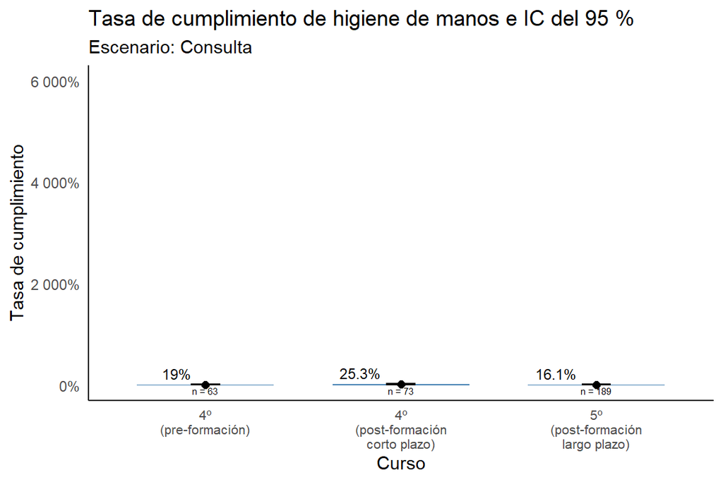

# Análisis de la proporción de acciones por curso, según indicación y escenario

- Para cada indicación de higiene de manos se muestra el número de oportunidades total y por curso.
- Se incluye el número de oportunidades aprovechas en cada curso y la tasa de cumplimiento que representan.
- La comparación de las tasas de cumplimiento entre los cursos (grupos independientes) se realiza a través de pruebas no paramétricas Chi-cuadrado o test exacto de Fisher.
- Un p-valor bajo indica evidencia estadísticamente significativa para no aceptar la hipótesis nula: existe evidencia de que la tasa de cumplimiento entre al menos dos de los grupos es diferente, según los datos recogidos.

```
Momento de Higiene de manos M1 (136 oprtunidades).
```

| **Characteristic** | **N** | **4º (pre-formación)** N = 5<sup>1</sup> | **4º (post-formación corto plazo)** N = 0<sup>1</sup> | **5º (post-formación largo plazo)** N = 131<sup>1</sup> | **p-value**<sup>2</sup> |
| --- | --- | --- | --- | --- | --- |
| accion | 136 | 0 (0%) | 0 (0%) | 96 (71%) | 0.002 |

<sup>1</sup> n (%)  
<sup>2</sup> Fisher’s exact test

```
Momento de Higiene de manos M2 (472 oprtunidades).
```

| **Characteristic** | **N** | **4º (pre-formación)** N = 173<sup>1</sup> | **4º (post-formación corto plazo)** N = 33<sup>1</sup> | **5º (post-formación largo plazo)** N = 266<sup>1</sup> | **p-value**<sup>2</sup> |
| --- | --- | --- | --- | --- | --- |
| accion | 472 | 29 (6.1%) | 24 (5.1%) | 59 (13%) | <0.001 |

<sup>1</sup> n (%)  
<sup>2</sup> Pearson’s Chi-squared test

```
Momento de Higiene de manos M3 (41 oprtunidades).
```

| **Characteristic** | **N** | **4º (pre-formación)** N = 26<sup>1</sup> | **4º (post-formación corto plazo)** N = 0<sup>1</sup> | **5º (post-formación largo plazo)** N = 15<sup>1</sup> | **p-value**<sup>2</sup> |
| --- | --- | --- | --- | --- | --- |
| accion | 41 | 1 (2.4%) | 0 (0%) | 1 (2.4%) | >0.9 |

<sup>1</sup> n (%)  
<sup>2</sup> Fisher’s exact test

```
Momento de Higiene de manos M4 (355 oprtunidades).
```

| **Characteristic** | **N** | **4º (pre-formación)** N = 158<sup>1</sup> | **4º (post-formación corto plazo)** N = 40<sup>1</sup> | **5º (post-formación largo plazo)** N = 157<sup>1</sup> | **p-value**<sup>2</sup> |
| --- | --- | --- | --- | --- | --- |
| accion | 355 | 8 (2.3%) | 13 (3.7%) | 11 (3.1%) | <0.001 |

<sup>1</sup> n (%)  
<sup>2</sup> Fisher’s exact test

```
Momento de Higiene de manos M5 (138 oprtunidades).
```

| **Characteristic** | **N** | **4º (pre-formación)** N = 9<sup>1</sup> | **4º (post-formación corto plazo)** N = 0<sup>1</sup> | **5º (post-formación largo plazo)** N = 129<sup>1</sup> | **p-value**<sup>2</sup> |
| --- | --- | --- | --- | --- | --- |
| accion | 138 | 0 (0%) | 0 (0%) | 15 (11%) | 0.6 |

<sup>1</sup> n (%)  
<sup>2</sup> Fisher’s exact test

# Análisis de la proporción de acciones por escenario, según indicación y curso

- Para cada indicación de higiene de manos se muestra el número de oportunidades total y por escenario
- Se incluye el número de oportunidades aprovechas en cada escenario y la tasa de cumplimiento que representan.
- La comparación de las tasas de cumplimiento entre los cursos (grupos independientes) se realiza a través de pruebas no paramétricas Chi-cuadrado o test exacto de Fisher.
- Un p-valor bajo indica evidencia estadísticamente significativa para no aceptar la hipótesis nula: existe evidencia de que la tasa de cumplimiento entre al menos dos de los escenarios es diferente, según los datos recogidos.

```
Momento de Higiene de manos Box (572 oprtunidades).
```

| **Characteristic** | **N** | **4º (pre-formación)** N = 308<sup>1</sup> | **4º (post-formación corto plazo)** N = 0<sup>1</sup> | **5º (post-formación largo plazo)** N = 264<sup>1</sup> | **p-value**<sup>2</sup> |
| --- | --- | --- | --- | --- | --- |
| accion | 572 | 14 (2.4%) | 0 (0%) | 8 (1.4%) | 0.4 |

<sup>1</sup> n (%)  
<sup>2</sup> Fisher’s exact test

```
Momento de Higiene de manos Consulta (325 oprtunidades).
```

| **Characteristic** | **N** | **4º (pre-formación)** N = 63<sup>1</sup> | **4º (post-formación corto plazo)** N = 73<sup>1</sup> | **5º (post-formación largo plazo)** N = 189<sup>1</sup> | **p-value**<sup>2</sup> |
| --- | --- | --- | --- | --- | --- |
| accion | 325 | 24 (7.4%) | 37 (11%) | 61 (19%) | 0.022 |

<sup>1</sup> n (%)  
<sup>2</sup> Pearson’s Chi-squared test

```
Momento de Higiene de manos Procedimiento invasivo (245 oprtunidades).
```

| **Characteristic** | **N** | **4º (pre-formación)** N = 0<sup>1</sup> | **4º (post-formación corto plazo)** N = 0<sup>1</sup> | **5º (post-formación largo plazo)** N = 245<sup>1</sup> | **p-value**<sup>2</sup> |
| --- | --- | --- | --- | --- | --- |
| accion | 245 | 0 (0%) | 0 (0%) | 113 (46%) | >0.9 |

<sup>1</sup> n (%)  
<sup>2</sup> Fisher’s exact test

# Modelos

Efecto de curso, indicación y escenario sobre la higiene de manos.

| Resultado | Qué afirmar |
| --- | --- |
| L ✔️ / Q ✔️ | Tendencia + curvatura |
| L ✔️ / Q ❌ | Tendencia lineal |
| L ❌ / Q ✔️ | Efecto no monótono |
| L ❌ / Q ❌ | Sin asociación detectable |

**Considerando el curso como ORDINAL para cuantificar el efecto tiempo** (no se trata como numérico ya que suponemos que no están igualmente espaciados).

| **Characteristic** | **log(OR)** | **95% CI** | **p-value** |
| --- | --- | --- | --- |
| curso |  |  |  |
| curso.L | -0.41 | -0.77, -0.04 | 0.030 |
| curso.Q | -0.77 | -1.3, -0.29 | 0.002 |
| indicacion |  |  |  |
| M1 | — | — |  |
| M2 | -1.6 | -2.3, -0.86 | <0.001 |
| M3 | -1.7 | -3.6, -0.25 | 0.040 |
| M4 | -3.0 | -3.9, -2.2 | <0.001 |
| M5 | -3.3 | -4.0, -2.6 | <0.001 |
| escenario |  |  |  |
| Box | — | — |  |
| Consulta | 2.8 | 2.3, 3.4 | <0.001 |
| Procedimiento invasivo | 3.0 | 2.3, 3.9 | <0.001 |

Abbreviations: CI = Confidence Interval, OR = Odds Ratio

**Note**

Parámetros lineal y cuadrático del factor curso significativos: existe una tendencia global a lo largo de los niveles PERO esa tendencia no es puramente lineal.  
- El efecto del ordinal no puede resumirse en un único “por nivel”.  
- Los cambios entre niveles no son constantes.  
- Algún nivel intermedio se comporta de forma distinta a lo esperado por una recta.

```
H0: el efecto de curso es lineal (modelo numérico es suficiente).
H1: el efecto no es lineal (modelo categórico ajusta mejor).
```

Prueba de razón de verosimilitud (LRT) para evaluar la linealidad del efecto de curso

| term | df.residual | residual.deviance | df | deviance | p valor |
| --- | --- | --- | --- | --- | --- |
| accion ~ as.numeric(curso) + indicacion + escenario | 1134 | 800.8306 | NA | NA | NA |
| accion ~ factor(curso) + indicacion + escenario | 1133 | 790.7713 | 1 | 10.05932 | <0.01 |

```
Se rechaza H0 (p < 0.05): el efecto de curso no es lineal y conviene tratarlo como factor.
```

```
Visualización del patrón no lineal.
```

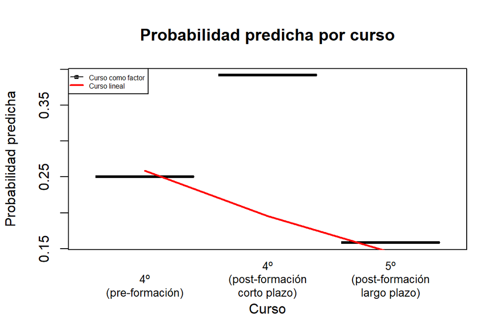

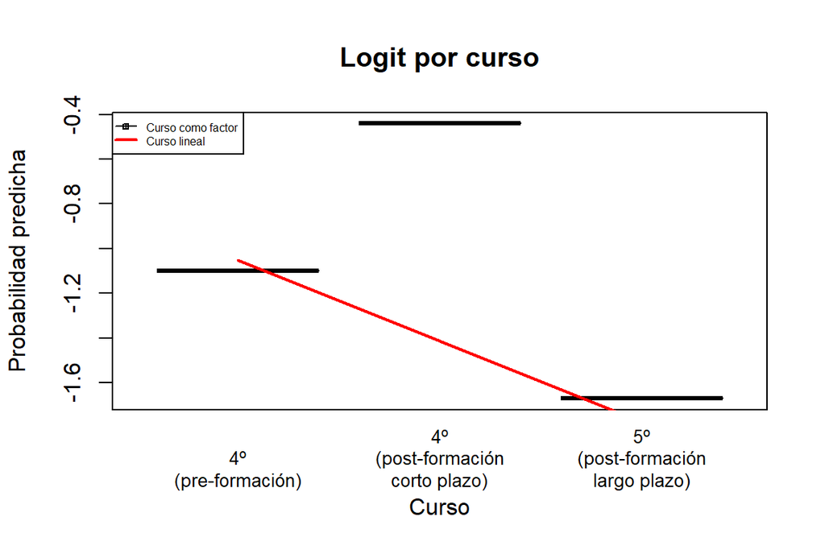

**Note**

- Los parámetros lineal y cuadrático del factor curso son significativo.
- El test LRT rechaza la hipótesis nula.
- La relación entre curso y la probabilidad predicha presenta diferencias por curso.

Hay evidencia de una relación no lineal entre el curso y la tasa de cumplimiento de higiene de manos.  
Por ello, no es apropiado usar odd ratios como medidas de interpretación del efecto, se recomiendo usar las medias marginales estimadas.  
(*emmeans: “¿Cuál es el riesgo en cada nivel específico del curso y cómo difieren entre sí?*”)

```
Medias marginales estimadas (probabilidad).
```

Medias marginales estimadas (probabilidad)

| curso | prob | SE | df | asymp.LCL | asymp.UCL |
| --- | --- | --- | --- | --- | --- |
| 4º (pre-formación) | 0.2592021 | 0.0475527 | Inf | 0.1771898 | 0.3624524 |
| 4º (post-formación corto plazo) | 0.4033476 | 0.0762740 | Inf | 0.2664469 | 0.5571622 |
| 5º (post-formación largo plazo) | 0.1647415 | 0.0263755 | Inf | 0.1193028 | 0.2231023 |

```
Comparaciones entre cursos.
```

Comparaciones pareadas entre niveles de curso usando estimaciones marginales

| contrast | estimate | SE | df | z.ratio | p valor |
| --- | --- | --- | --- | --- | --- |
| (4º (pre-formación)) - (4º (post-formación corto plazo)) | -0.6585838 | 0.3496758 | Inf | -1.883412 | 0.143 |
| (4º (pre-formación)) - (5º (post-formación largo plazo)) | 0.5732440 | 0.2645314 | Inf | 2.167016 | <0.1 |
| (4º (post-formación corto plazo)) - (5º (post-formación largo plazo)) | 1.2318277 | 0.3077471 | Inf | 4.002727 | <0.001 |

Tip. Si estimate > 0: primer grupo tiene mayor media. Si estimate < 0: segundo grupo tiene mayor media.  
- **pre vs post-corto**. Diferencia negativa (post-corto > pre): la tasa aumenta a corto plazo pero no es significativo.  
- **pre vs post-largo**. Diferencia positiva (post-largo < pre): la tasa disminuye a largo plazo pero no es significativo.  
- **post-corto vs post-largo**. Diferencia positiva (post-largo < post-corto), la tasa disminuye con el tiempo en los cursos post-formación y la disminución sí es significativa.

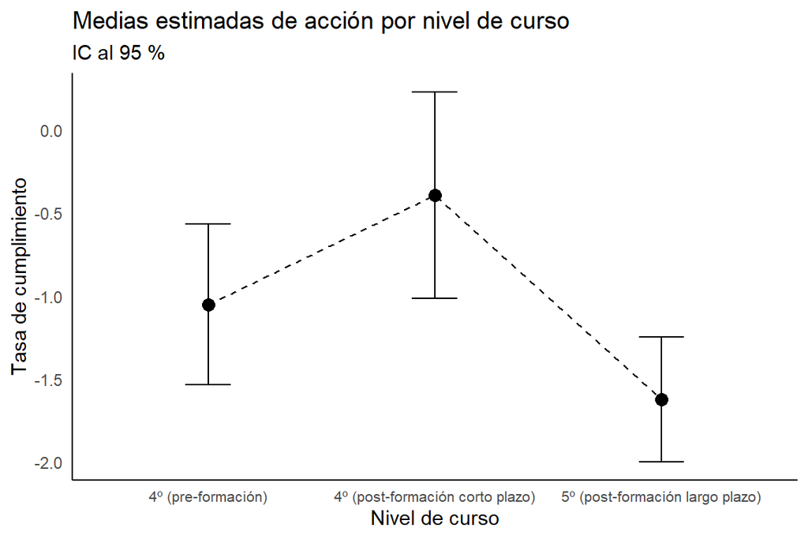

**Important**

Se vuelve a estimar el efecto del curso en la tasa de cumplimiento **solo en el escenario de Consulta**.

| **Characteristic** | **log(OR)** | **95% CI** | **p-value** |
| --- | --- | --- | --- |
| curso |  |  |  |
| curso.L | -0.41 | -0.87, 0.05 | 0.083 |
| curso.Q | -0.88 | -1.4, -0.37 | <0.001 |
| indicacion |  |  |  |
| M1 | — | — |  |
| M2 | -1.1 | -4.1, 1.3 | 0.4 |
| M4 | -2.8 | -5.9, -0.39 | 0.026 |
| M5 | -1.8 | -5.8, 1.5 | 0.3 |

Abbreviations: CI = Confidence Interval, OR = Odds Ratio

```
H0: el efecto de curso es lineal (modelo numérico es suficiente).
H1: el efecto no es lineal (modelo categórico ajusta mejor).
```

Prueba de razón de verosimilitud (LRT) para evaluar la linealidad del efecto de curso

| term | df.residual | residual.deviance | df | deviance | p valor |
| --- | --- | --- | --- | --- | --- |
| accion ~ as.numeric(curso) + indicacion | 320 | 391.9817 | NA | NA | NA |
| accion ~ factor(curso) + indicacion | 319 | 380.2034 | 1 | 11.77831 | <0.001 |

```
Se rechaza H0 (p < 0.05): el efecto de curso no es lineal y conviene tratarlo como factor.
```

```
Visualización del patrón no lineal.
```

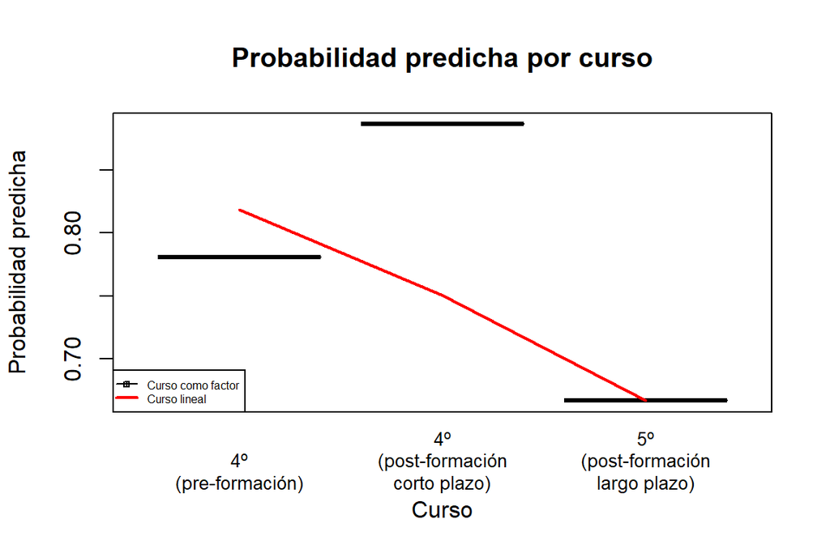

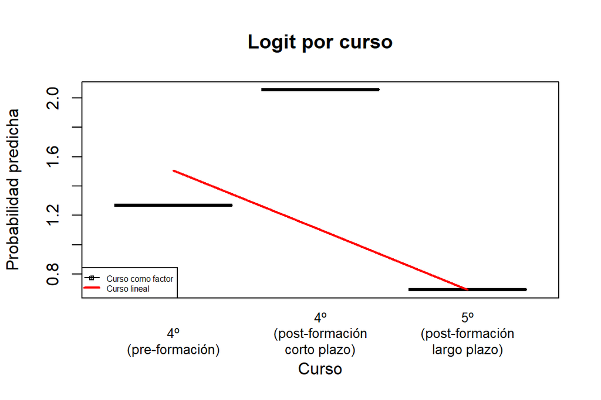

**Note**

Hay evidencia de una relación no lineal entre el curso y la tasa de cumplimiento de higiene de manos.  
Por ello, no es apropiado usar odd ratios como medidas de interpretación del efecto, se recomiendo usar las medias marginales estimadas.  
(*emmeans: “¿Cuál es el riesgo en cada nivel específico del curso y cómo difieren entre sí?*”)

```
Medias marginales estimadas (probabilidad).
```

Medias marginales estimadas (probabilidad)

| curso | prob | SE | df | asymp.LCL | asymp.UCL |
| --- | --- | --- | --- | --- | --- |
| 4º (pre-formación) | 0.4650606 | 0.1234428 | Inf | 0.2474034 | 0.6968911 |
| 4º (post-formación corto plazo) | 0.6560655 | 0.1160066 | Inf | 0.4105151 | 0.8393575 |
| 5º (post-formación largo plazo) | 0.3280542 | 0.1004945 | Inf | 0.1665148 | 0.5440192 |

```
Comparaciones entre cursos.
```

Comparaciones pareadas entre niveles de curso usando estimaciones marginales

| contrast | estimate | SE | df | z.ratio | p valor |
| --- | --- | --- | --- | --- | --- |
| (4º (pre-formación)) - (4º (post-formación corto plazo)) | -0.7857955 | 0.3896175 | Inf | -2.016838 | 0.108 |
| (4º (pre-formación)) - (5º (post-formación largo plazo)) | 0.5770131 | 0.3323323 | Inf | 1.736254 | 0.192 |
| (4º (post-formación corto plazo)) - (5º (post-formación largo plazo)) | 1.3628085 | 0.3303295 | Inf | 4.125603 | <0.001 |

Tip. Si estimate > 0: primer grupo tiene mayor media. Si estimate < 0: segundo grupo tiene mayor media.  
- pre vs post-corto. Diferencia negativa (post-corto > pre): la tasa aumenta a corto plazo pero no es significativo.  
- pre vs post-largo. Diferencia positiva (post-largo < pre): la tasa disminuye a largo plazo pero no es significativo.  
- post-corto vs post-largo**. Diferencia positiva (post-largo < post-corto), la tasa disminuye con el tiempo en los cursos post-formación y la disminución sí es significativa.

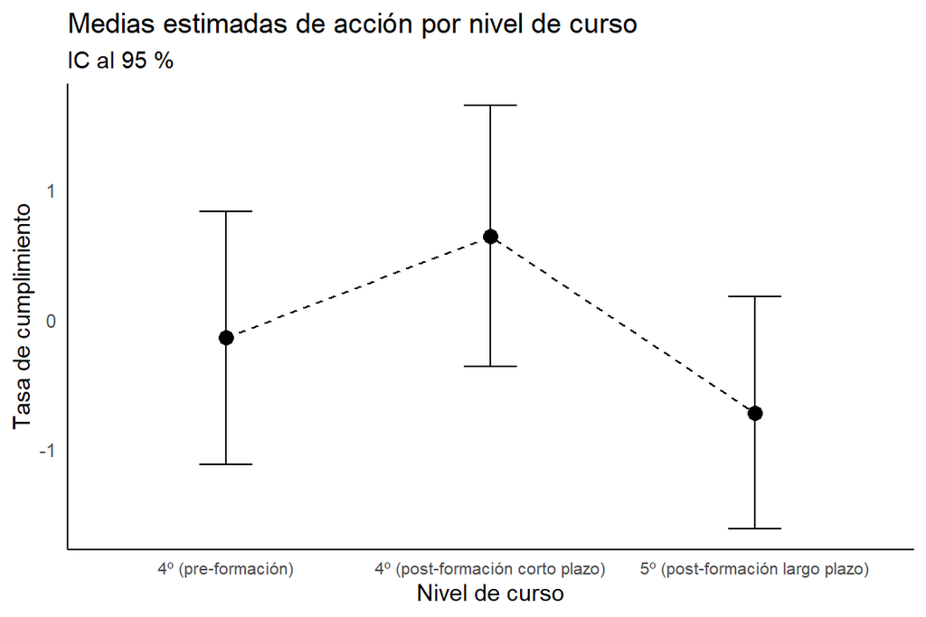